# STT864 HW1

qinhao zhang

January 25, 2016

### Q1 Read those dataset into R.

```r
chromoX<-read.table(file='ChromoXmicroarray.txt',header = TRUE)
ordered.ChromoXsnp<-read.table(file="ChromoXsnp.txt",header=TRUE)
readsnpIDs<-read.table(file="SNPsampleIDs.txt")
readmicroIDs<-read.table(file="MicroarraysampleIDs.txt")
```

### Q2 Find the gene expressions of gene’CSF2RA’ using the gene IDENTIFER.

we only include the first one and those columns with gene expression value.

```r
CSF2RA2<-chromoX[which(chromoX$IDENTIFIER=='CSF2RA'),][1,3:49]
```

### Q3 Find the two SNPs that are nearest to the gene ‘CSF2RA’.

```r
nearestSNPs<-ordered.ChromoXsnp[which(ordered.ChromoXsnp$Physical.Position==min(ordered.ChromoXsnp$Physical.Position)),]

nearestSNPs2<-ordered.ChromoXsnp[2,]
```

### Q4 Are there misising values? Any non-response? Are they categorical data or numerical continous data or numerical counts data?

There are missing values. In `ChromoXsnp` dataset, the number `4` implies missing value. This is a categorial data.

### Q5 Data cleaning and organizing:

remove the mising value; We only include the column with gene expression values.

```r
nearestSNPs.total<-rbind(nearestSNPs,nearestSNPs2)
nearestSNPs.total[apply(nearestSNPs.total,2,function(x) x%in%'4')]<-NA
rr<-na.omit(t(as.data.frame(nearestSNPs.total[,1:78])))
nomissingSNPs<-as.data.frame(t(rr))
```

combine the SNPs dataset and microarray dataset.

```r
cname<-colnames(nomissingSNPs)
for(i in 1:length(cname)){
 cname[i]<-as.character(readsnpIDs[grep(cname[i],as.character(readsnpIDs[,1])),2])
}
colnames(nomissingSNPs)<-cname


mname<-colnames(CSF2RA2)
for(i in 1:length(mname)){
  mname[i]<-as.character(readmicroIDs[grep(mname[i],as.character(readmicroIDs[,1])),2])
}
colnames(CSF2RA2)<-mname
```

We have already changded the colname of the data. Now we have to match it.

```r
finalSNPs<-nomissingSNPs[,colnames(nomissingSNPs)%in%colnames(CSF2RA2)]
finalCSF2RA2<-CSF2RA2[,colnames(CSF2RA2)%in%colnames(finalSNPs)]


finalCSF2RA2<-finalCSF2RA2[,order(colnames(finalCSF2RA2))]
finalSNPs<-finalSNPs[,order(colnames(finalSNPs))]

finaldata<-rbind(finalCSF2RA2,finalSNPs)
```

For convinience we change the row names of the dataset.

```r
rownames(finaldata)<-c('Geneexpression','SNP1','SNP2')
```

Here is the final dataset we get. For convinence we only include the first 10 colunm

|  | T115 | T116 | T117 | T118 | T119 | T123 | T129 | T133 | T134 | T137 |
| --- | --- | --- | --- | --- | --- | --- | --- | --- | --- | --- |
| Geneexpression | 3.549 | 3.23 | 3.454 | 3.422 | 3.045 | 5.821 | 2.84 | 6.414 | 3.919 | 4.409 |
| SNP1 | 3.000 | 1.00 | 1.000 | 3.000 | 2.000 | 3.000 | 3.00 | 1.000 | 3.000 | 3.000 |
| SNP2 | 1.000 | 1.00 | 3.000 | 1.000 | 1.000 | 1.000 | 1.00 | 1.000 | 1.000 | 1.000 |

### Q6 give summary statistics for the microarry data and SNPs data.

For convinence, we transpose the dataset first.

```r
tfinaldata<-t(finaldata)
```

Here is the summary statistics for the gene expression:

```r
summary(tfinaldata[,1])
```

```
##    Min. 1st Qu.  Median    Mean 3rd Qu.    Max.
##   2.485   3.045   3.422   3.681   4.059   6.414
```

Here is the summary statistic(frequency) for SNP1:

```r
table(tfinaldata[,2])
```

```
##
##  1  2  3
##  4  4 21
```

Here is the summary statistic(frequency) for SNP2:

```r
table(tfinaldata[,3])
```

```
##
##  1  2  3
## 27  1  1
```

### Q7 Give a histogram of the microarry dataset

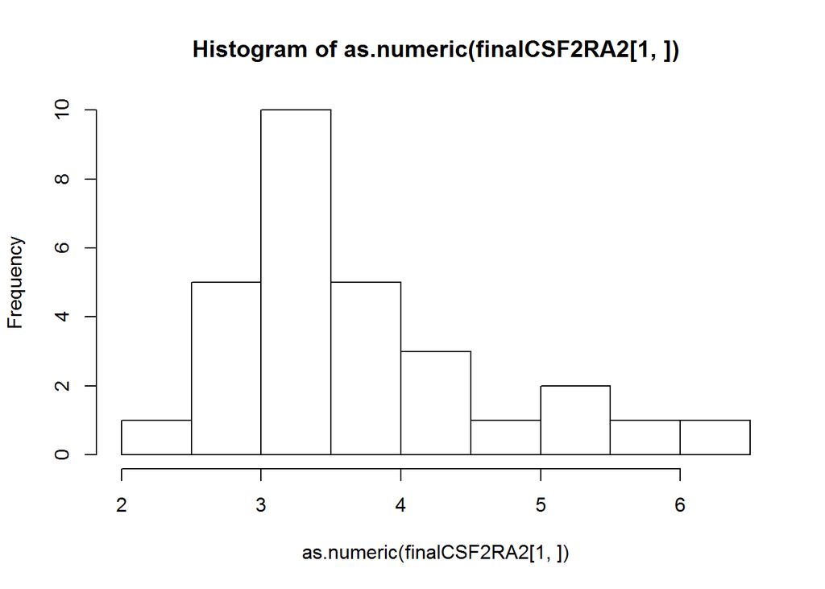

```r
hist(as.numeric(finalCSF2RA2[1,]))
```

The distribution is right skewd.

### Q8 Check the relationship between SNPs and microarray data

```r
cor1<-cor(tfinaldata[,1],tfinaldata[,2])
cor2<-cor(tfinaldata[,1],tfinaldata[,3])
```

The corelation coeffieients between geneexpression and SNP1 is -0.0964255; the corelation coeffieients between geneexpression and SNP2 is -0.1198457. So we can say that there are little corelation between them.

Draw a scatter plot of SNP and microarray data.

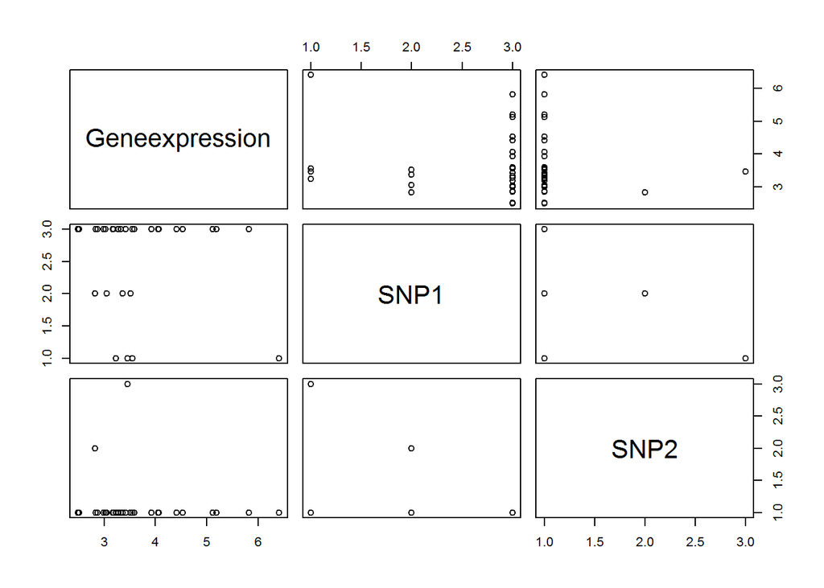

```r
pairs(tfinaldata)
```

If we consider the SNPs data as categorical dataset, we could draw boxplots of microarray data according to the value of SNPs.

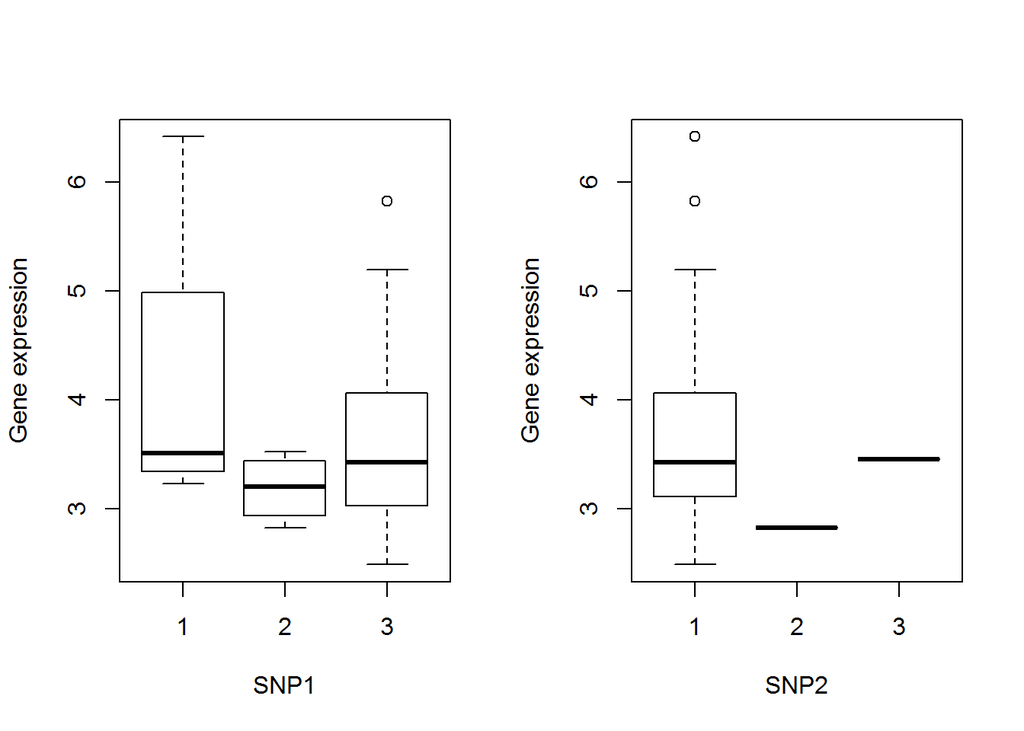

```r
par(mfrow=c(1,2))
boxplot(Geneexpression~SNP1,data=tfinaldata,xlab='SNP1',ylab='Gene expression')
boxplot(Geneexpression~SNP2,data=tfinaldata,xlab='SNP2',ylab='Gene expression')
```

### Q9 Describle the two-way ANOVA model in statistical formulation for this dataset.

The model with interaction: $Y_{ij}=\mu+\tau_{i}+\beta_{j}+\gamma_{ij}+\epsilon_{ijk}$,$\epsilon \backsim N(0,\sigma^2)$

The model without interaction: $Y_{ij}=\mu+\tau_{i}+\beta_{j}+\epsilon_{ijk}$,$\epsilon \backsim N(0,\sigma^2)$

### Q10 Fit the two-way ANOVA model using R.And can we fit a model with interaction for this dataset?

Prepare the data

```r
geneex<-as.data.frame(tfinaldata)$Geneexpression
SNP1<-as.data.frame(tfinaldata)$SNP1
SNP2<-as.data.frame(tfinaldata)$SNP2
```

Fit the model without interaction:

```r
model1<-lm(geneex~SNP1+SNP2)
anova(model1)
```

```
## Analysis of Variance Table
##
## Response: geneex
##           Df  Sum Sq Mean Sq F value Pr(>F)
## SNP1       1  0.2373 0.23727  0.2525 0.6196
## SNP2       1  0.8480 0.84799  0.9024 0.3509
## Residuals 26 24.4338 0.93976
```

The model with interaction:

```r
model2<-lm(geneex~SNP1+SNP2+(SNP1*SNP2))
anova(model2)
```

```
## Analysis of Variance Table
##
## Response: geneex
##           Df  Sum Sq Mean Sq F value Pr(>F)
## SNP1       1  0.2373 0.23727  0.2470 0.6235
## SNP2       1  0.8480 0.84799  0.8827 0.3565
## SNP1:SNP2  1  0.4166 0.41665  0.4337 0.5162
## Residuals 25 24.0172 0.96069
```

Studying the output of the ANOVA table we see that there is no evidence of asignificant interaction effect.We therefore cannot conclude that there is an interaction between SNP1 and SNP2.

The interaction plot.

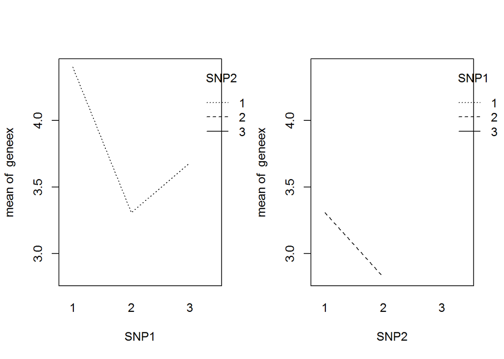

```r
par(mfrow=c(1,2))
interaction.plot(SNP1,SNP2,geneex)
interaction.plot(SNP2,SNP1,geneex)
```

The interaction plot tells us what the interaction effect look like. In this plot the vertical axis represents the group averages of the target variable, with the categories of one effect along the horizontal axis, and different lines representing the categories of the other effect.If no interaction effect is present in the data, the lines in the interaction plot should be roughly parallel, so lack of parallelism in the lines supports the existence of an interaction effect.

But we can only see one line from the interaction plot. So I think we could not judge whether there exist interaction effect or not.

I think we could try a model with interaction for this dataset. There are posibilities that the two SNPs work together to influence the gene expression. But from the fitted model, we can see that there are no interaction effect , so the model with interaction is not correct.

### Q11 Some ideas about improve the model

More sample size. In our study mthe sample size is 29, it is not large enough.

Model diagnostic

### Q12 Check if the model is sufficient.

The fitted value versus residuals plot

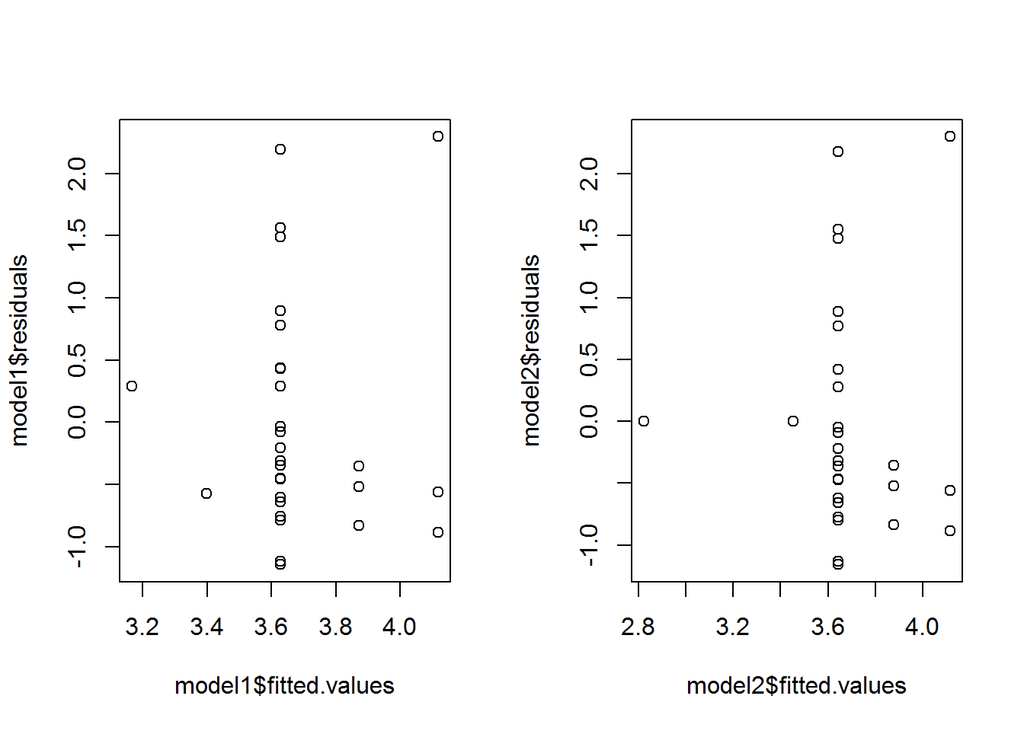

```r
par(mfrow=c(1,2))
plot(model1$fitted.values,model1$residuals)
plot(model2$fitted.values,model2$residuals)
```

### Q13 Check the normality assumption.

One of the assumption of ANOVA model is that the error term are normal distributed. So we have to check the normality.

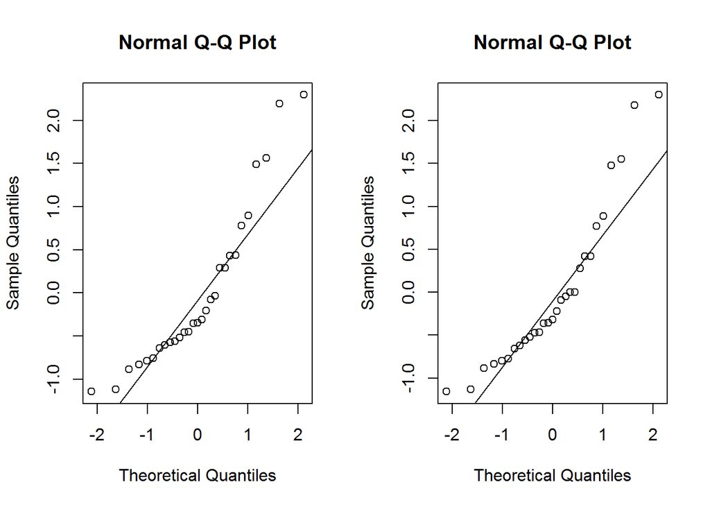

```r
par(mfrow=c(1,2))
qqnorm(model1$residuals)
qqline(model1$residuals)

qqnorm(model2$residuals)
qqline(model2$residuals)
```

As we can see from the picture, it is nearly normal distributed.

If the two-way ANOVA model without interaction is sufficient.

### Q14 Are these two SNPs associated with the gene expression of “CSF2RA”?

According to the ANOVA model, these two SNPs are not associated with the gene expression.

```r
anova(model1)
```

```
## Analysis of Variance Table
##
## Response: geneex
##           Df  Sum Sq Mean Sq F value Pr(>F)
## SNP1       1  0.2373 0.23727  0.2525 0.6196
## SNP2       1  0.8480 0.84799  0.9024 0.3509
## Residuals 26 24.4338 0.93976
```

According to the ANOVA table, the p value is greater than 0.05. It is not significant.

### Q15 For SNP1, check if the effects of the two alleles on the gene expression are the same.

We have to use dominant model or addictive model to transform the data first.  
Addictive model: *AA: 2b1 Aa: b1 aa: 0*

```r
geneex<-as.numeric(finaldata[1,])
SNP1<-as.numeric(finaldata[2,])-1
summary(lm(geneex~SNP1))$coefficients
```

```
##               Estimate Std. Error    t value     Pr(>|t|)
## (Intercept)  3.8799587  0.4347306  8.9249719 1.535797e-09
## SNP1        -0.1256261  0.2495617 -0.5033872 6.187744e-01
```

The p-value is greater than 0.05, so it is not significant. The effect of two alleles are not different.

Dominate models: *AA:b2; Aa:b2; aa:0* or *AA:0; Aa:b2; aa:b2*

```r
# AA:b2; Aa:b2; aa:0
SNP1<-as.numeric(((finaldata[2,]-1)!=0)+0)
summary(lm(geneex~SNP1))$coefficients
```

```
##             Estimate Std. Error   t value     Pr(>|t|)
## (Intercept)  4.16375  0.4756705  8.753432 2.277334e-09
## SNP1        -0.56035  0.5123129 -1.093765 2.837205e-01
```

The p-value is greater than 0.05, so it is not significant. The effect of two alleles are not different.

```r
# AA:0; Aa:b2; aa:b2
SNP1<-as.numeric(((finaldata[2,]-1)!=2)+0)
summary(lm(geneex~SNP1))$coefficients
```

```
##                 Estimate Std. Error     t value     Pr(>|t|)
## (Intercept)  3.682761905  0.2121476 17.35943003 3.567819e-16
## SNP1        -0.007511905  0.4039170 -0.01859764 9.852988e-01
```

The p-value is greater than 0.05, so it is not significant. The effect of two alleles are not different.